# CAP A UNA EDUCACIÓ DE QUALITAT I PER A TOTHOM EN EL MARC DE L’AGENDA 2030

Jana Roma

5/5/2022

Despesa total en educació:

| country | education_expenditure | expenditure (gdp percentage) |
| --- | --- | --- |
| Luxembourg | 21244.393 | 3.236180 |
| Austria | 15096.620 | 4.772443 |
| Norway | 14848.056 | 6.633411 |
| United States | 13511.180 | 6.133827 |
| Iceland | 13254.115 | 5.806358 |
| Belgium | 13053.996 | 5.673050 |
| Sweden | 12338.735 | 5.436250 |
| Germany | 12194.609 | 4.221165 |
| Denmark | 12162.510 | 5.480444 |
| Switzerland | 12137.763 | NA |
| Netherlands | 11931.437 | 5.166924 |
| United Kingdom | 11597.240 | 6.263126 |
| Canada | 11380.129 | 5.901097 |
| Australia | 11269.766 | 5.977944 |
| France | 10866.623 | 5.200071 |
| Finland | 10133.012 | 5.193935 |
| Italy | 10035.590 | 3.851249 |
| Japan | 9962.514 | 4.013060 |
| Portugal | 9835.583 | 5.165367 |
| Slovenia | 9223.022 | 4.235565 |
| Ireland | 9217.520 | 3.420654 |
| Spain | 9165.503 | 4.286160 |
| Israel | 9063.787 | 6.211842 |
| Czech Republic | 8052.356 | 3.630441 |
| Poland | 7596.918 | 4.295920 |
| Estonia | 7462.406 | 4.387382 |
| Hungary | 6779.867 | 3.945270 |
| Latvia | 6765.898 | 4.006010 |
| Greece | 6198.875 | NA |
| Lithuania | 6094.263 | 3.413439 |
| Chile | 5212.860 | 6.328322 |
| Turkey | 4594.486 | 5.011014 |
| Colombia | 3136.789 | 5.683366 |
| Mexico | 2802.561 | 4.394697 |

Ordenat segons percentatge PIB:

| country | education_expenditure | expenditure (gdp percentage) |
| --- | --- | --- |
| Norway | 14848.056 | 6.633411 |
| Chile | 5212.860 | 6.328322 |
| United Kingdom | 11597.240 | 6.263126 |
| Israel | 9063.787 | 6.211842 |
| United States | 13511.180 | 6.133827 |
| Australia | 11269.766 | 5.977944 |
| Canada | 11380.129 | 5.901097 |
| Iceland | 13254.115 | 5.806358 |
| Colombia | 3136.789 | 5.683366 |
| Belgium | 13053.996 | 5.673050 |
| Denmark | 12162.510 | 5.480444 |
| Sweden | 12338.735 | 5.436250 |
| France | 10866.623 | 5.200071 |
| Finland | 10133.012 | 5.193935 |
| Netherlands | 11931.437 | 5.166924 |
| Portugal | 9835.583 | 5.165367 |
| Turkey | 4594.486 | 5.011014 |
| Austria | 15096.620 | 4.772443 |
| Mexico | 2802.561 | 4.394697 |
| Estonia | 7462.406 | 4.387382 |
| Poland | 7596.918 | 4.295920 |
| Spain | 9165.503 | 4.286160 |
| Slovenia | 9223.022 | 4.235565 |
| Germany | 12194.609 | 4.221165 |
| Japan | 9962.514 | 4.013060 |
| Latvia | 6765.898 | 4.006010 |
| Hungary | 6779.867 | 3.945270 |
| Italy | 10035.590 | 3.851249 |
| Czech Republic | 8052.356 | 3.630441 |
| Ireland | 9217.520 | 3.420654 |
| Lithuania | 6094.263 | 3.413439 |
| Luxembourg | 21244.393 | 3.236180 |
| Switzerland | 12137.763 | NA |
| Greece | 6198.875 | NA |

Mirem si hi ha relació entre el que es gasten els països en educació i els seus resutats als tests estandaritzats:

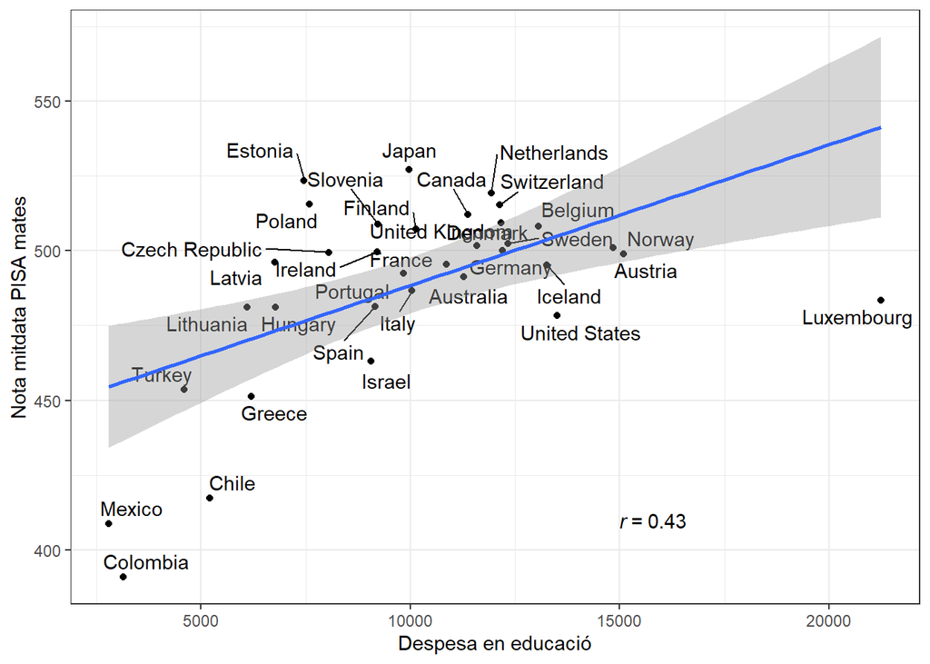

Veiem que hi ha relació, amb un coeficient de correlació del 0.43, per tant una correlació moderada. Fixeu-vos però, que, justament Estats Units, destaca per tenir resultats força més baixos dels que els tocaria per despesa.

A què es pot deure això? Aquí la intuïció del Marc crec que l’encerta de plè. Mirem els resulats d’USA per ètnia:

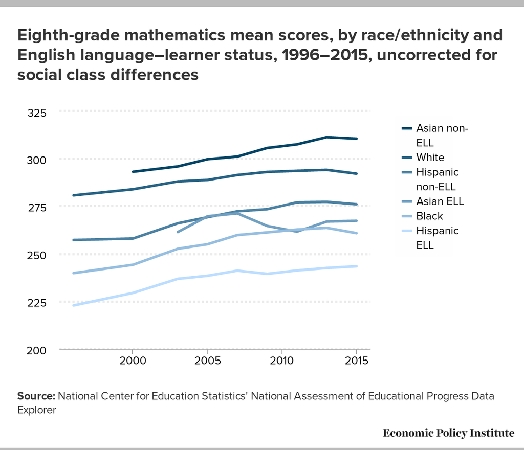

Resultats tests nacionals per ètnia

Aquí hi ha un efecte de l’ètnia ja conegut pel què fa als infants d’origen asiàtic, però, en la resta, el que pesa més és el nivell socioeconòmic (les persones de minories ètniques gairebé sempre són més pobres):

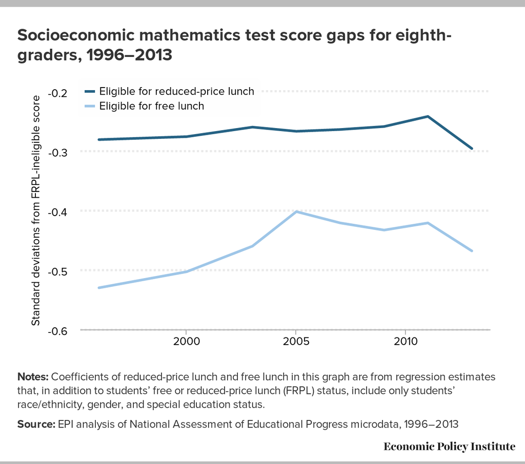

Per tant, veiem que un dels problemes principals és el rendiment de les persones més desafavorides.

A EUA, com sabeu, hi ha molta desigualtat econòmica i cultural. Mirem com de gran és aquesta desigualtat i com afecta el rendiment acadèmic comparant totes les països:

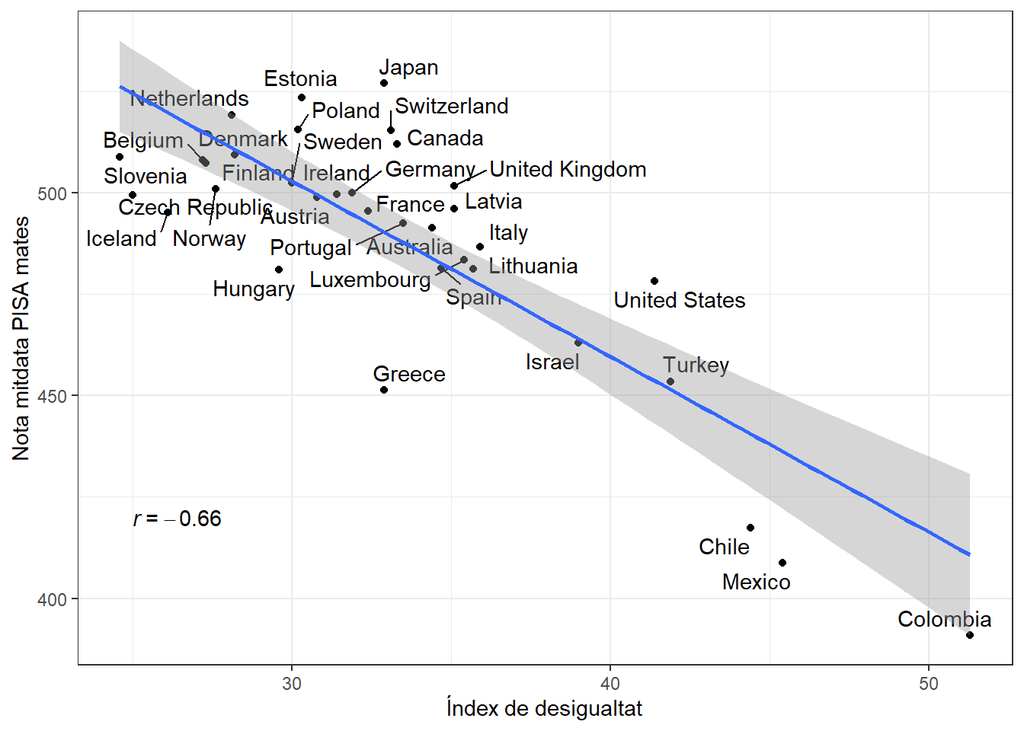

Mirem també el rendiment acadèmic segons el producte interior brut per càpita:

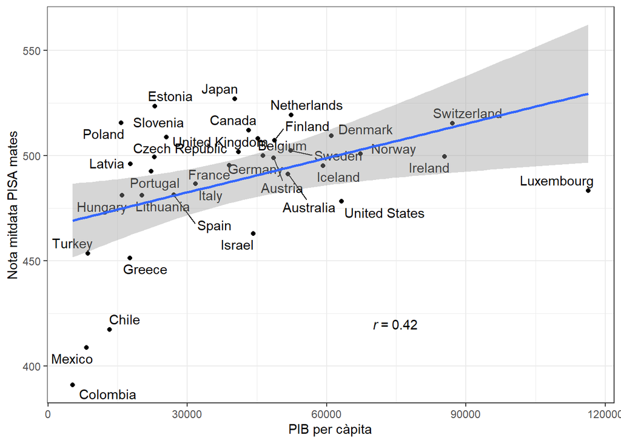

La correlació és força menor.

Ho mirarem ara segons despesa pública i privada:

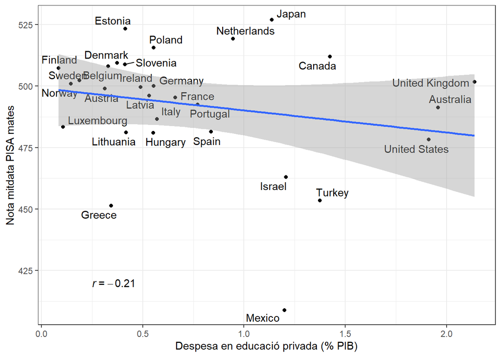

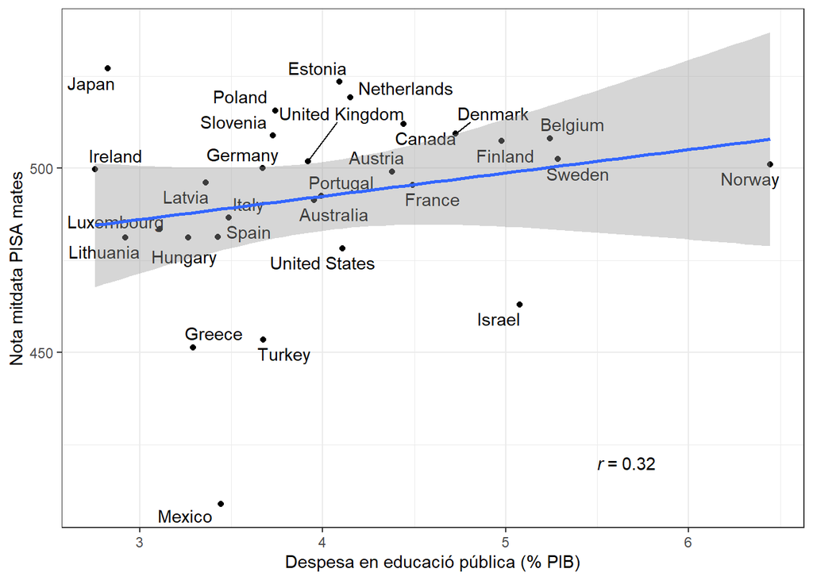

Despesa privada i gini:

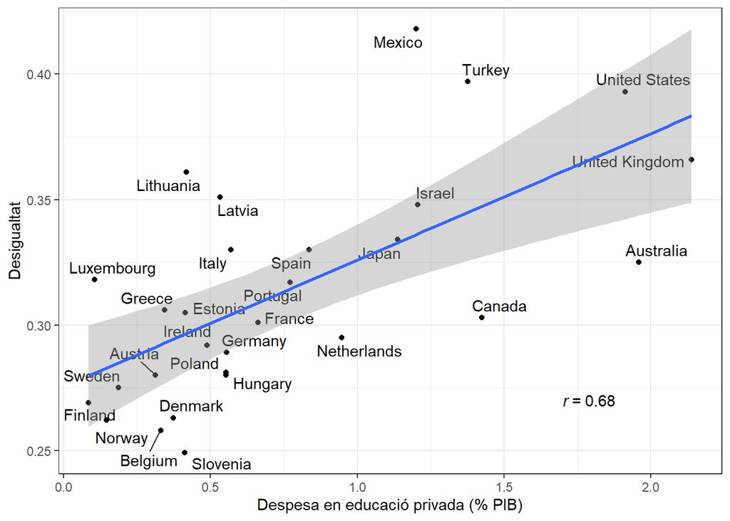

Despesa pública i gini:

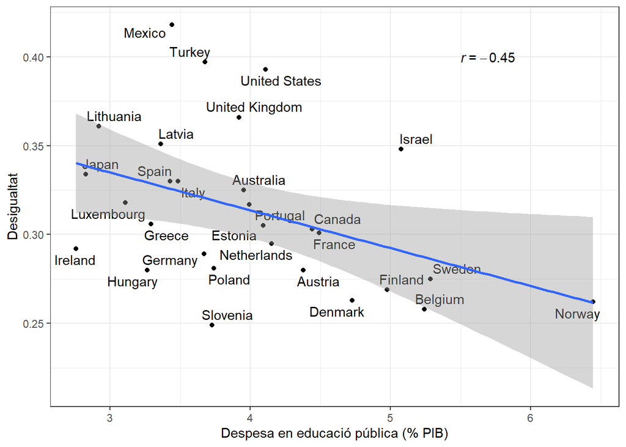

## Evolucions

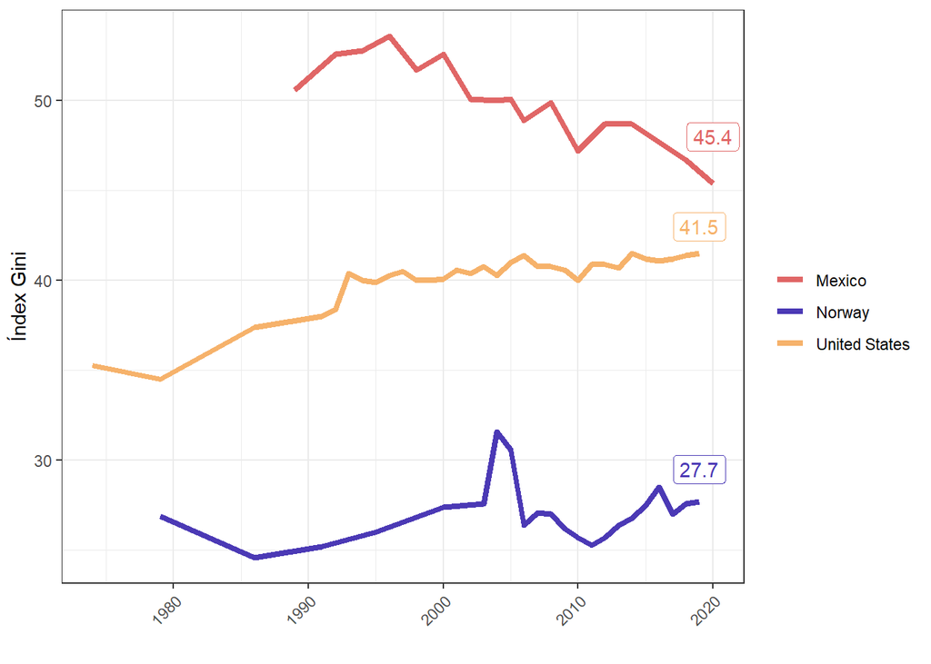

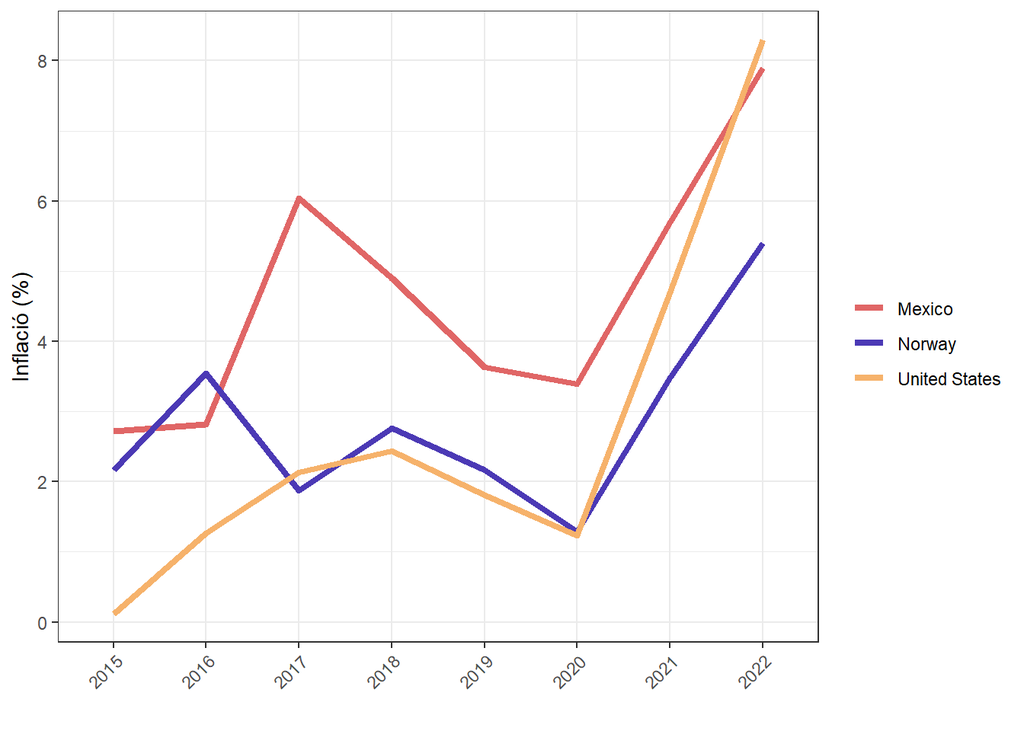

## Models

Mirem quina de les tres variables (PIB per càpita, despesa en educació o índex de desigualtat) afecta més al rendiment acadèmic segons PISA:

```
## Algorithms Trained: Random Forest, eXtreme Gradient Boosting, and glmnet
## Model Name: math_score
## Target: math_score
## Class: Regression
## Performance Metric: RMSE
## Number of Observations: 34
## Number of Features: 3
## Models Trained: 2022-05-20 10:26:14
##
## Models tuned via 5-fold cross validation over 10 combinations of hyperparameter values.
## Best model: eXtreme Gradient Boosting
## RMSE = 0.55, MAE = 0.42, Rsquared = 0.66
## Optimal hyperparameter values:
##   nrounds = 280
##   max_depth = 9
##   eta = 0.14
##   gamma = 2.5
##   colsample_bytree = 0.61
##   min_child_weight = 2.5
##   subsample = 0.61
```

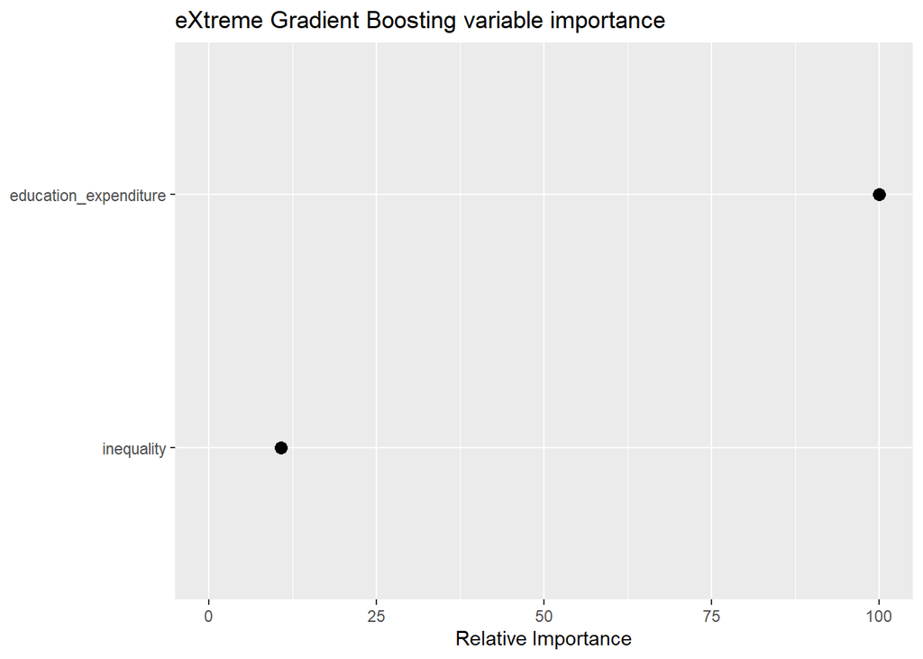

Segons la regressió:

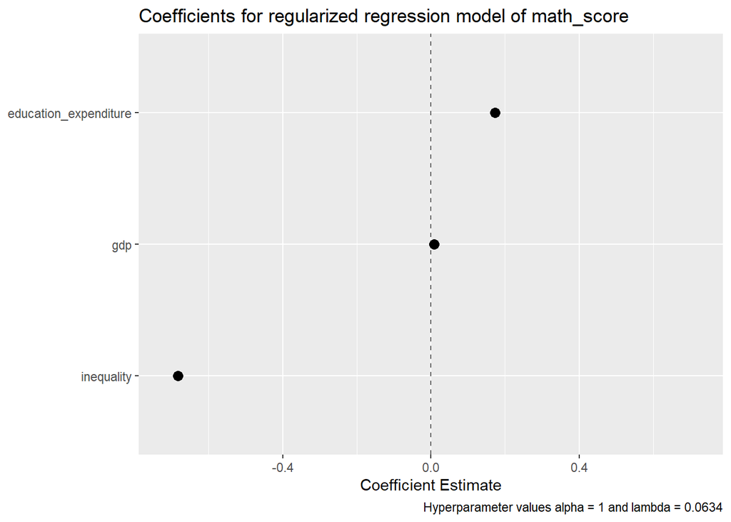

Molt interessant! La desigualtat és el factor més important, i per això USA té resultats baixos, però que compensa **una mica** gastant-se molts diners (i, per això, en el gràfic de índex de desigualtat vs nota mitdata, surten per sobre de la línia blava).